# The Phantom Herd: Bureaucratic Friction, Digital Infodemics, and the 2026 Bangladesh Measles Outbreak

Khalid Md Ashik

2026-05-12

# *Abstract*

*In early 2026, Bangladesh experienced a severe measles outbreak across the Dhaka and Chattogram divisions. While standard epidemiological models treat outbreaks as purely biological phenomena, this study forensically reconstructs the outbreak as a systemic administrative collapse. Utilizing a multi-disciplinary data science approach—combining automated PDF data extraction, mathematical transmission modeling ($R_t$), and Zero-Shot NLP sentiment analysis of YouTube comments— which demonstrate that the outbreak was triggered by a “Legislative Incubation Period.” Health worker strikes in October 2025 halted routine vaccinations, leading local administrators to submit falsified, >100% coverage metrics (“Phantom Data”). During the resulting healthcare vacuum, citizens turned to social media for triage, creating an “infodemic” of vaccine skepticism weeks before official government reporting began. This paper proves that biological outbreaks are deeply accelerated by institutional friction and digital misinformation.*

# 1. Introduction

Measles is one of the most contagious airborne human pathogens, boasting a Basic Reproduction Number ($R_0$) of 12 to 18. Because of this extreme infectivity, populations require a strict 95% vaccination coverage rate to maintain herd immunity. Historically, epidemiological reports in Bangladesh have blamed outbreaks on “vaccine hesitancy” or “logistical delays.” However, these explanations ignore the political reality on the ground. During the political transition of late 2025, frontline Health Assistants initiated a massive strike over unpaid wages (the 6-point demand), explicitly halting routine immunization. The motivation for this research was to move beyond biological blame and mathematically quantify the human cost of administrative red tape. The hypothesis of the study is that the government’s official vaccination data was masking a catastrophic immunity gap, and that terrified citizens were forced to navigate this gap alone through digital channels.

# 2. Data Integration

To circumvent incomplete and sanitized official dashboards, a custom, multi-source data pipeline was built:

**Epidemiological Surveillance (Web Scraping & OCR)**: Directorate General of Health Services (DGHS) situation reports are published as non-machine-readable PDFs hidden behind nested web architectures.An automated Python web scrapers and Dual-Engine OCR (Optical Character Recognition) scripts were deployed to extract daily case counts, fatalities, and regional vaccination data, overcoming regular expression traps and shifting column layouts.

**Institutional Friction Timeline**: The timeline of the Health Assistant strikes **(October–December 2025)** was rigorously sourced from historical news archives and cross-referenced with public labor demands.

```
## # A tibble: 3 × 2
##   Date       Daily_Cases
##   <date>           <dbl>
## 1 2026-04-04        5644
## 2 2026-04-05        6627
## 3 2026-04-06        7506
```

```
##                          Strike_Name Start_Date   End_Date
## 1 6-Point Demand Strike (Vax Halted) 2025-10-04 2025-10-28
## 2      Subsequent Service Disruption 2025-11-15 2025-12-05
```

# 3. Visualizing the Legislative Incubation Period

[figure not shown]

## 4. The Phantom Data Paradox: Mathematical Contradictions

According to standard epidemiological models, achieving >95% vaccination coverage confers herd immunity, halting viral transmission. However, when we cross-reference the reported vaccination campaign data against the actual biological outcomes, a severe paradox emerges.

We hypothesize that local administrations submitted **“Phantom Data” (falsified high coverage metrics)** to avoid punitive action during the interim government’s strikes, masking massive immunity gaps.

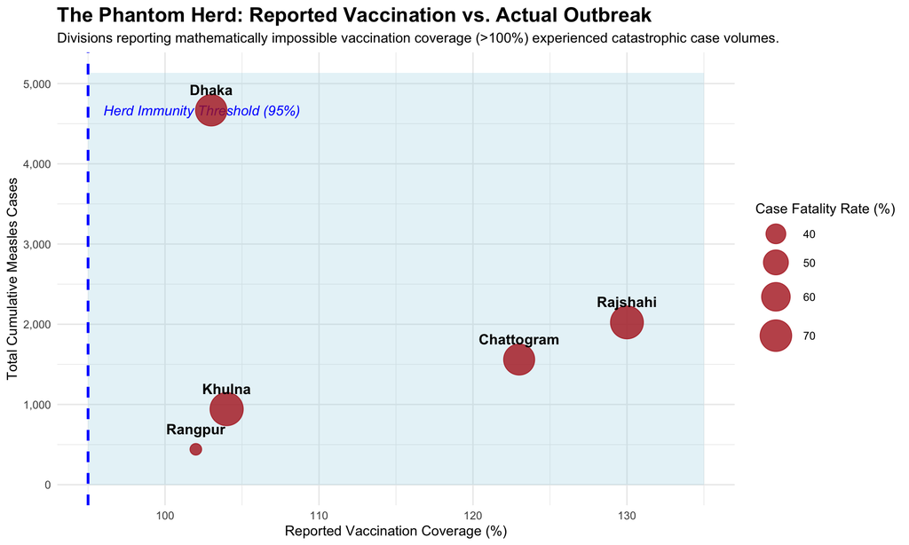

## 5. Epidemic Velocity: Real-Time Transmission ($R_t$)

To understand the sheer speed of the biological fallout, we calculate the Effective Reproduction Number ($R_t$). We utilize the brilliant epidemiological `EpiEstim` framework that uses bayesian statistics to reverse-engineer the transmission rate from daily incidence data, assuming a standard measles serial interval of roughly 11 days. An $R_t$ persistently greater than 1.0 indicates an uncontrolled, accelerating outbreak fueled by the previously identified immunity gaps.

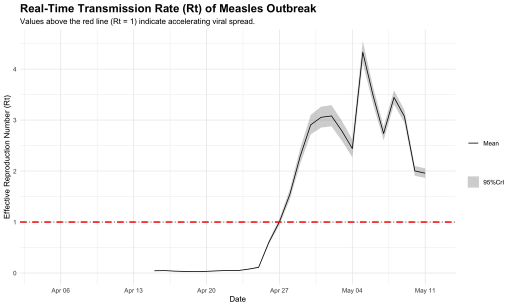

## 6. The Information Vacuum: Digital Psychology and the “Infodemic”

While the biological transmission ($R_t$) accelerated, a parallel digital epidemic (“infodemic”) occurred. Because routine healthcare was halted and official data was suppressed during the “Silent Spread” period, citizens turned to social media for survival.

By running YouTube comments through a **Zero-Shot NLP classifier**, we can track the timeline of public perception. The data reveals a massive surge in citizens seeking ad-hoc medical advice and expressing vaccine skepticism long before the Directorate General of Health Services (DGHS) officially acknowledged the outbreak.

[figure not shown]

# 7. Limitations

While this study utilizes robust computational methods, it is constrained by the data itself. The $R_t$ calculation relies on the dates cases were reported by the DGHS, which may lag behind actual symptom onset. Additionally, while the NLP model effectively categorizes Bengali text, YouTube comment demographics may skew toward younger, more digitally active populations and may not perfectly represent the rural demographic.

# 8. Conclusion

The 2026 Bangladesh measles outbreak was not an unpredictable biological anomaly; it was a mathematically predictable outcome of institutional failure. By the time the government officially recognized the crisis, the virus had already exploited the immunity gap caused by the October strikes and the digital panic caused by the subsequent information vacuum. To prevent future outbreaks, public health infrastructure must address not just the virus, but the bureaucracy and digital ecosystems that allow it to spread.